# DATA622_HW4

- Female - 37%
- Male - 21%

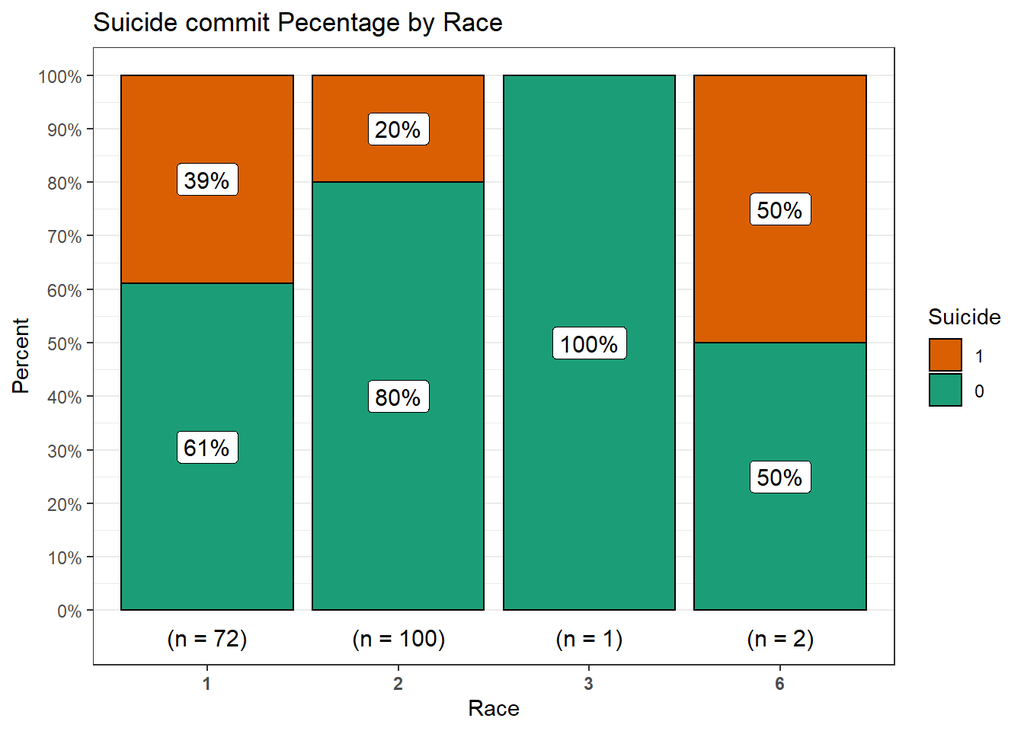

```r
p <- data_all %>% select(c('Race','Suicide'))
PlotXTabs2(p, Race, Suicide, results.subtitle = FALSE, title ="Suicide commit Pecentage by Race")
```

Suicide committed by Race:

- Other - 50%
- White - 39%
- African American - 20%

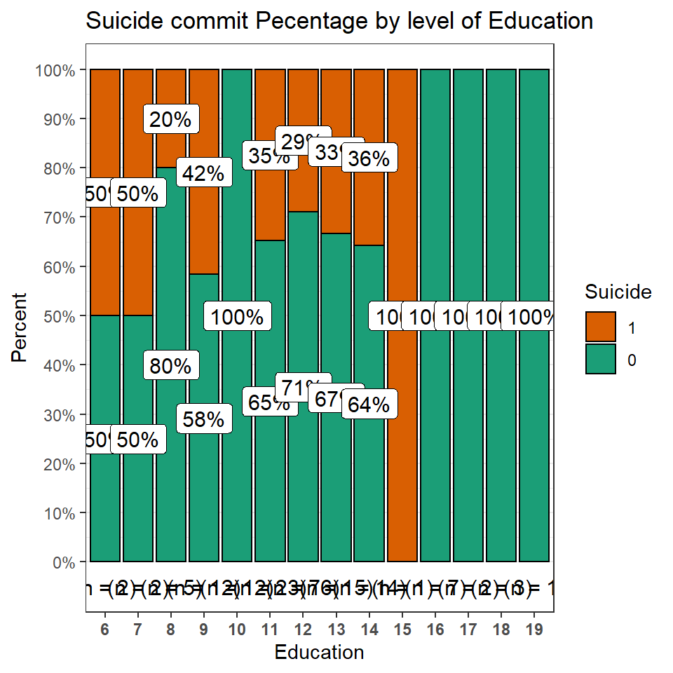

```r
p <- data_all %>% select(c('Education','Suicide'))
PlotXTabs2(p, Education, Suicide, results.subtitle = FALSE, title ="Suicide commit Pecentage by level of Education")
```

Higher educated less likely committed suicide than others.

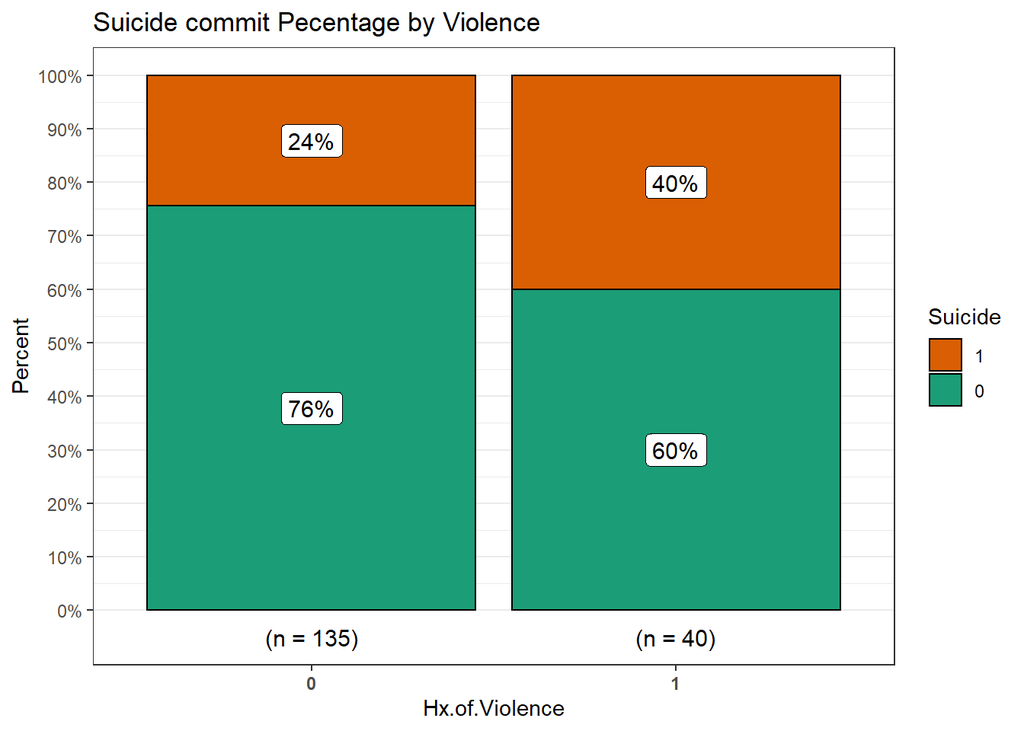

```r
p <- data_all %>% select(c('Hx.of.Violence','Suicide'))
PlotXTabs2(p, Hx.of.Violence, Suicide, results.subtitle = FALSE, title ="Suicide commit Pecentage by Violence")
```

Violant people commited more suicide than non-violant.

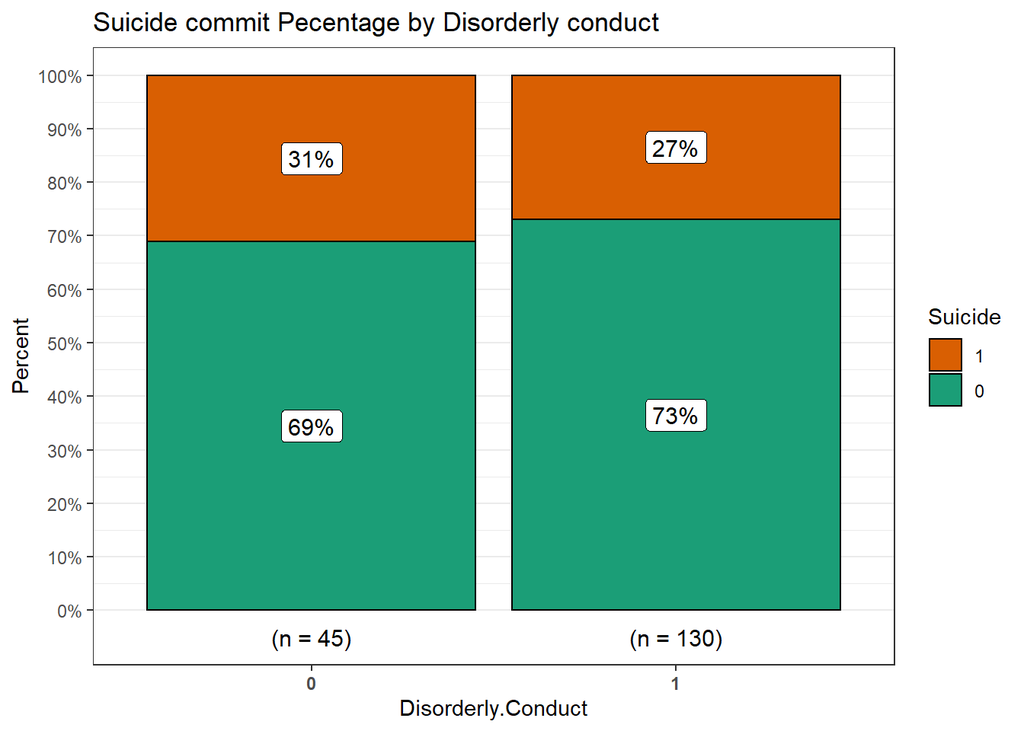

```r
p <- data_all %>% select(c('Disorderly.Conduct','Suicide'))
PlotXTabs2(p, Disorderly.Conduct, Suicide, results.subtitle = FALSE, title ="Suicide commit Pecentage by Disorderly conduct")
```

This is little surprising, non Disorderly conduct committed more suicide than Disorderly Conduct.

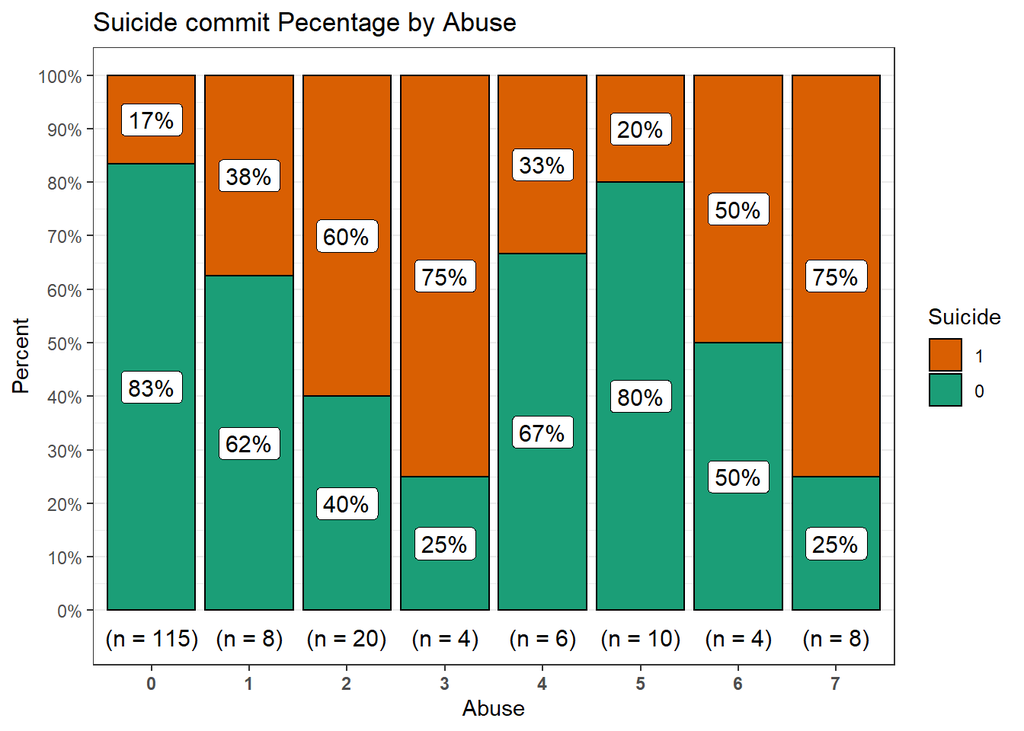

```r
p <- data_all %>% select(c('Abuse','Suicide'))
PlotXTabs2(p, Abuse, Suicide, results.subtitle = FALSE, title ="Suicide commit Pecentage by Abuse")
```

Suicide commit by Abuse category:

- Emotional and P&S&E - 75%
- Sexual - 60%
- S&E - 50%
- P&S - 33%

Other abuse category are less.

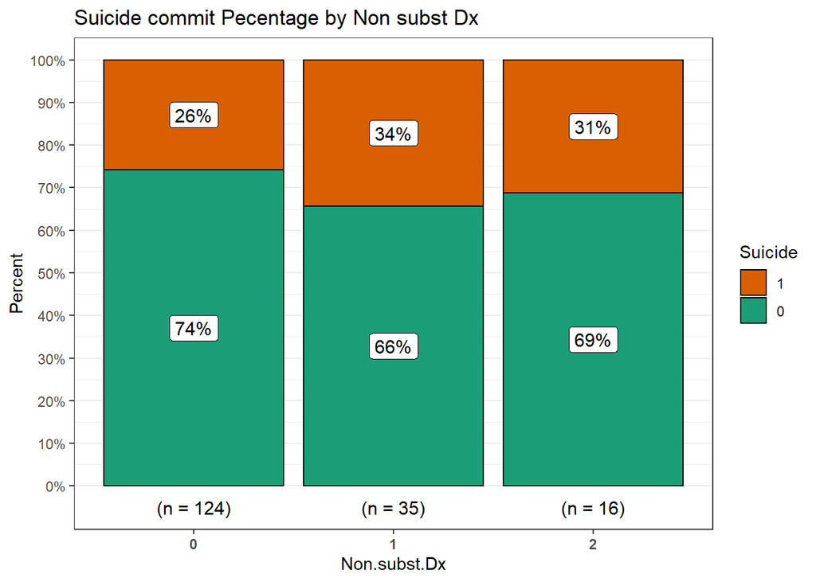

```r
p <- data_all %>% select(c('Non.subst.Dx','Suicide'))
PlotXTabs2(p, Non.subst.Dx, Suicide, results.subtitle = FALSE, title ="Suicide commit Pecentage by Non subst Dx")
```

Non-substance related Dx : Suicide commit Non-subset Dx one is highest and Non-substance related Dx none is lowest.

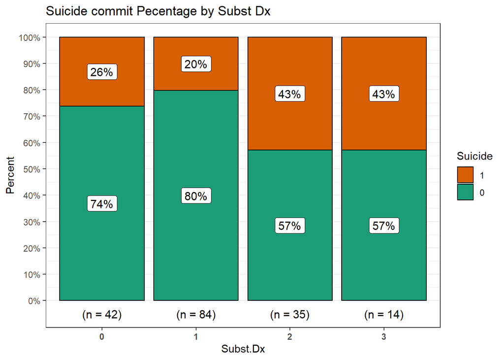

```r
p <- data_all %>% select(c('Subst.Dx','Suicide'))
PlotXTabs2(p, Subst.Dx, Suicide, results.subtitle = FALSE, title ="Suicide commit Pecentage by Subst Dx")
```

Substance related Dx : Suicide commit substance related Dx two and three are highest and substance related Dx one is lowest.

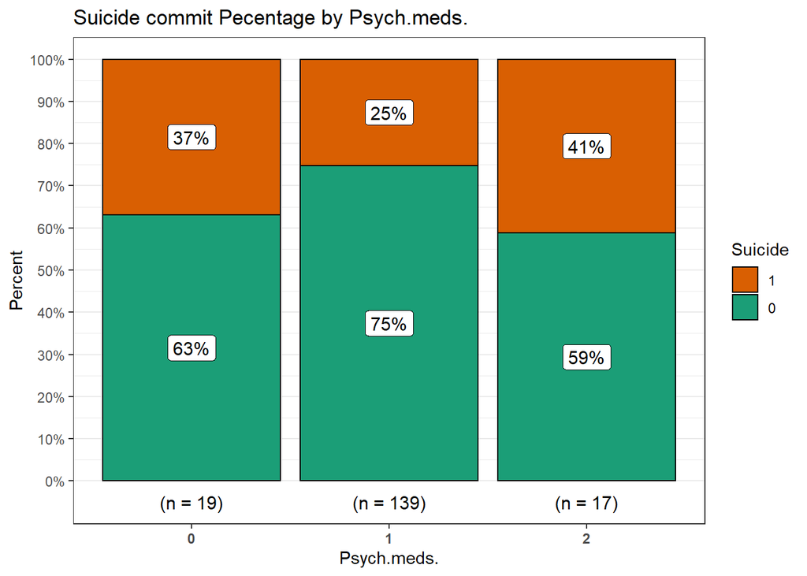

```r
p <- data_all %>% select(c('Psych.meds.','Suicide'))
PlotXTabs2(p, Psych.meds., Suicide, results.subtitle = FALSE, title ="Suicide commit Pecentage by Psych.meds.")
```

Suicide commit by Psychiatric Meds:

- more than one psychotropic med - 41%
- one psychotropic med - 25%
- None - 37%

### SVM Model: entire dataset and PCA output

We will perform SVM with entire dataset. Then, create another SVM model on reduced dimension which performed PCA with `genl` dataset. Compare the result matrices of these model to find the best one.

```r
data_all_new <- data_all %>% select(-Suicide, everything())

#Set set (replicability)
set.seed(700)

#Perform train-test Split
intrain <- createDataPartition(data_all_new$Suicide, p = 0.75, list = FALSE)
training_all <- data_all_new[intrain,]
test_all <- data_all_new[-intrain,]
results <- test_all$Suicide #hold actual test values for later comparison
test_all$Suicide <- NA


gammalist <- c(0.005,0.01,0.015,0.02,0.025,0.03,0.035,0.04,0.045,0.05)
tune.out_radial <- tune.svm(as.factor(Suicide) ~., data=training_all,
                 kernel='radial', cost=2^(1:5), gamma = gammalist)

tune.out_linear <- tune.svm(as.factor(Suicide) ~., data=training_all,
                 kernel='linear', cost=2^(1:5), gamma = gammalist)

svm3 <- predict(tune.out_radial$best.model, test_all[,-dim(test_all)[2]])
svm4 <- predict(tune.out_linear$best.model, test_all[,-dim(test_all)[2]])

#Convert performance statistics to tabular form (for output / interpretation):
AccuracySVM3 <- confusionMatrix(svm3, as.factor(results))$overall['Accuracy']
AccuracySVM4 <- confusionMatrix(svm4, as.factor(results))$overall['Accuracy']

SVM_Model_3 <- confusionMatrix(svm3, as.factor(results))$byClass
SVM_Model_3 <- data.frame(SVM_Model_3)
SVM_Model_3 <- rbind("Accuracy" = AccuracySVM3, SVM_Model_3)

SVM_Model_4 <- confusionMatrix(svm4, as.factor(results))$byClass
SVM_Model_4 <- data.frame(SVM_Model_4)
SVM_Model_4 <- rbind("Accuracy" = AccuracySVM4, SVM_Model_4)

tabularview <- data.frame(SVM_Model_3, SVM_Model_4)
tabularview %>%  kableExtra::kbl() %>% kable_styling(bootstrap_options = c("striped", "hover", "condensed", "responsive"),latex_options="scale_down")
```

|  | SVM_Model_3 | SVM_Model_4 |
| --- | --- | --- |
| Accuracy | 0.8604651 | 0.8604651 |
| Sensitivity | 0.9189189 | 0.8918919 |
| Specificity | 0.5000000 | 0.6666667 |
| Pos Pred Value | 0.9189189 | 0.9428571 |
| Neg Pred Value | 0.5000000 | 0.5000000 |
| Precision | 0.9189189 | 0.9428571 |
| Recall | 0.9189189 | 0.8918919 |
| F1 | 0.9189189 | 0.9166667 |
| Prevalence | 0.8604651 | 0.8604651 |
| Detection Rate | 0.7906977 | 0.7674419 |
| Detection Prevalence | 0.8604651 | 0.8139535 |
| Balanced Accuracy | 0.7094595 | 0.7792793 |

The models share the same Accuracy and Neg Pred Value, whereas SVM_Model_3 (radial) outperformed SVM_Model_4 (linear) in Sensitivity, Recall, Detection Ratee, F1, and Detection Prevalence while SVM_Model_4 (linear) outperformed SVM_Model_3 (radial) for Specificity, Pos Pred Value, Precision, and Balanced Accuracy.

### SVM Model: PCA output

From `Varimax` plot we found, to get above 90% variance in data we need to include 11 principal components. We are going to exclude ‘ADHD.Total’,‘Non.subst.Dx’, ‘Subst.Dx’, from the dataset.

Split the data in to train and test, apply model, fit the model, predict the model using test data, calculate results matrices to see the model performance.

```r
genl_2 <- data[c(2:4,23,39)]
genl_2$SUB.Total <- sub$SUB.Total
genl_2 <- cbind(genl_2, hstry)

# imputation
genl_3 <- genl_2 %>%
  mutate(
    SUB.Total = impute(SUB.Total, mode),
    Court.order = impute(Court.order, mode),
    Education = impute(Education, mode),
    Hx.of.Violence = impute(Hx.of.Violence, mode),
    Disorderly.Conduct = impute(Disorderly.Conduct, mode),
    Suicide = impute(Suicide, mode),
    Abuse = impute(Abuse, mode),
    Non.subst.Dx = impute(Non.subst.Dx, mode),
    Subst.Dx = impute(Subst.Dx, mode),
    Psych.meds. = impute(Psych.meds., mode)
    ) %>%
  mutate_if(is.character, as.numeric)
```

```r
genl_svm <- genl_3 %>% select(-c('ADHD.Total', 'Non.subst.Dx', 'Subst.Dx')) %>% select(-Suicide, everything())

#Set set (replicability)
set.seed(900)

#Perform train-test Split
intrain <- createDataPartition(genl_svm$Suicide, p = 0.75, list = FALSE)
training_not_all <- genl_svm[intrain,]
test_not_all <- genl_svm[-intrain,]
results_not_all <- test_not_all$Suicide #hold actual test values for later comparison
test_not_all$Suicide <- NA


gammalist <- c(0.005,0.01,0.015,0.02,0.025,0.03,0.035,0.04,0.045,0.05)

tune.out_radial_5 <- tune.svm(as.factor(Suicide) ~., data=training_not_all,
                 kernel='radial', cost=2^(1:5), gamma = gammalist)

tune.out_linear_6 <- tune.svm(as.factor(Suicide) ~., data=training_not_all,
                 kernel='linear', cost=2^(1:5), gamma = gammalist)

svm5 <- predict(tune.out_radial_5$best.model, test_not_all[,-dim(test_not_all)[2]])
svm6 <- predict(tune.out_linear_6$best.model, test_not_all[,-dim(test_not_all)[2]])

#Convert performance statistics to tabular form (for output / interpretation):
AccuracySVM5 <- confusionMatrix(svm5, as.factor(results_not_all))$overall['Accuracy']
AccuracySVM6 <- confusionMatrix(svm6, as.factor(results_not_all))$overall['Accuracy']

SVM_Model_5 <- confusionMatrix(svm5, as.factor(results_not_all))$byClass
SVM_Model_5 <- data.frame(SVM_Model_5)
SVM_Model_5 <- rbind("Accuracy" = AccuracySVM5, SVM_Model_5)

SVM_Model_6 <- confusionMatrix(svm6, as.factor(results_not_all))$byClass
SVM_Model_6 <- data.frame(SVM_Model_6)
SVM_Model_6 <- rbind("Accuracy" = AccuracySVM6, SVM_Model_6)

tabularview <- data.frame(SVM_Model_3, SVM_Model_4, SVM_Model_5, SVM_Model_6)
tabularview %>%  kableExtra::kbl() %>% kable_styling(bootstrap_options = c("striped", "hover", "condensed", "responsive"),latex_options="scale_down")
```

|  | SVM_Model_3 | SVM_Model_4 | SVM_Model_5 | SVM_Model_6 |
| --- | --- | --- | --- | --- |
| Accuracy | 0.8604651 | 0.8604651 | 0.7441860 | 0.6744186 |
| Sensitivity | 0.9189189 | 0.8918919 | 0.9655172 | 1.0000000 |
| Specificity | 0.5000000 | 0.6666667 | 0.2857143 | 0.0000000 |
| Pos Pred Value | 0.9189189 | 0.9428571 | 0.7368421 | 0.6744186 |
| Neg Pred Value | 0.5000000 | 0.5000000 | 0.8000000 | NaN |
| Precision | 0.9189189 | 0.9428571 | 0.7368421 | 0.6744186 |
| Recall | 0.9189189 | 0.8918919 | 0.9655172 | 1.0000000 |
| F1 | 0.9189189 | 0.9166667 | 0.8358209 | 0.8055556 |
| Prevalence | 0.8604651 | 0.8604651 | 0.6744186 | 0.6744186 |
| Detection Rate | 0.7906977 | 0.7674419 | 0.6511628 | 0.6744186 |
| Detection Prevalence | 0.8604651 | 0.8139535 | 0.8837209 | 1.0000000 |
| Balanced Accuracy | 0.7094595 | 0.7792793 | 0.6256158 | 0.5000000 |

We extend the following commentary based on the above output:

- Model 5 (Radial) has high accuracy, Precision, and F1 than Model 6 (linear).
- Model 5 works fine with predicting ‘no’ but have higher class error in predicting ‘yes’. Similarly, Model 6 correctly predict for ‘no’ but completely incorrectly predict for ‘yes’. Incorrect prediction on ‘yes’ class may be the cause of Multicollinearity.
- Model 3 and Model 4 are the better models than Model 5 and Model 6 aspect of accuracy, Specificity, F1.